# funcoes-trigonometricas

#### $$ \text{---\{ Trigonometria \}---} \ \\ $$

### $$ \text{Funções Trigonométricas} $$

$$ \text{Prof. Eduardo Ono} \ \\[24pt] $$

**Sumário**

- 1. Objetivos
- 1. Funções Trigonométricas
  - 2.1. Definição
- 1. Função Seno: $\ y = \text{sen }x\ $
  - 3.1. Definição
  - 3.2. Gráfico
- 1. Função Cosseno: $\ y = \cos x\ $
  - 4.1. Definição
  - 4.2. Gráfico
- 1. Função Tangente: $\ y = \text{tg }x\ $
  - 5.1. Propriedades
  - 5.2. Gráfico

```python
import matplotlib.pyplot as plt

plt.rcParams['figure.figsize'] = [6, 4]
```

# 1. Objetivos

- Conceituar as funções trigonométricas;
- Definir as principais funções trigonométricas: Seno, Cosseno e Tangente;
- Construir os gráficos das principais funções trigonométricas;
- Aplicar os conceitos na resolução de problemas.

# 2. Funções Trigonométricas

## 2.1. Definição

**Funções trigonométricas** são aplicações de $\mathbb{R}$ sobre o ciclo trigonométrico $\lambda$, onde podemos associar a cada número real $x$ um único ponto $P$ de $\lambda$ do seguinte modo:

1. Se $\,x = 0\,$, então $P$ coincide com $A$;
2. Se $\,x > 0\,$, então realizamos a partir de $A$ um percurso de comprimento $x$, no sentido anti-horário, e marcamos $P$ como ponto final do percurso;
3. Se $\,x < 0\,$, então realizamos a partir de $A$ um percurso de comprimento $|x|$, no sentido horário. O ponto final do percurso é $P$.

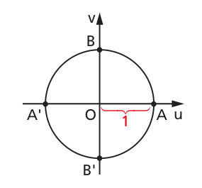

Fonte: Iezzi

O ponto $P$ é a imagem dos elementos do conjunto

$$ \{x \in \mathbb{R}\ | \ x = x_0 + 2k\pi, \ k \in \mathbb{Z}\} $$

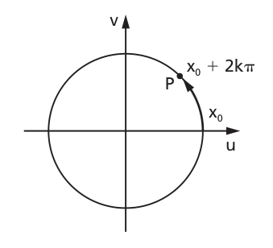

Fonte: Iezzi

# 3. Função Seno: $\ y = \text{sen }x\ $

## 3.1. Definição

Denominamos **função seno** a função $\,f: \mathbb{R} \longrightarrow \mathbb{R}\,$ que associa a cada real $x$ o real $\,OP_1 = \text{sen }x\,$, isto é:

$$ f(x) = \text{sen }x $$

## 3.2. Gráfico

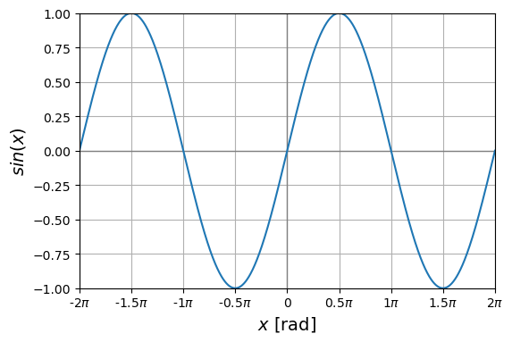

```python
import numpy as np
import math

x_min = -2 * math.pi
x_max = 2 * math.pi
x_step = (x_max - x_min) / 1000
y_min = -1
y_max = 1
plt.xlabel("$x$ [rad]", fontsize=14)
plt.ylabel("$sin(x)$", fontsize=14)
x_values = np.arange(x_min, x_max + x_step, x_step)
y_values = np.sin(x_values)

plt.grid()
plt.axhline(y=0.0, color='grey', linestyle='-', linewidth=1)
plt.axvline(x=0.0, color='grey', linestyle='-', linewidth=1)
plt.xlim(x_min, x_max)
plt.ylim(y_min, y_max)
radian_multiples = np.arange(x_min / math.pi, x_max / math.pi + 0.5, 0.5) # [-2, -3/2, -1, -1/2, 0, 1/2, 1, 3/2]
radians = [n * math.pi for n in radian_multiples]
radian_labels = []
for n in radian_multiples:
    label = '0' if n == 0 else rf'{int(n)}$\pi$' if n == int(n) else rf'{n}$\pi$'
    radian_labels.append(label)

plt.xticks(radians, radian_labels)
plt.plot(x_values, y_values)
plt.show()
```

# 4. Função Cosseno: $\ y = \cos x\ $

## 4.1. Definição

Denominamos **função cosseno** a função $\,f: \mathbb{R} \longrightarrow \mathbb{R}\,$ que associa a cada real $x$ o real $\,OP_2 = \cos x\,$, isto é:

$$ f(x) = \cos x $$

## 4.2. Gráfico

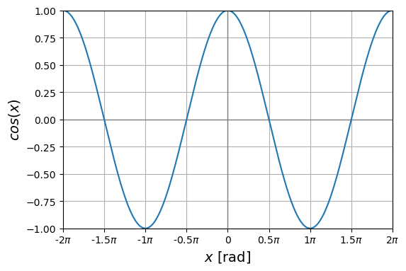

```python
import numpy as np
import math

x_min = -2 * math.pi
x_max = 2 * math.pi
x_step = (x_max - x_min) / 1000
x_values = np.arange(x_min, x_max + x_step, x_step)
y_values = np.cos(x_values)

plt.grid()
plt.axhline(y=0.0, color='grey', linestyle='-', linewidth=1)
plt.axvline(x=0.0, color='grey', linestyle='-', linewidth=1)
plt.xlim(x_min, x_max)
plt.xlabel("$x$ [rad]", fontsize=14)
plt.ylabel("$cos(x)$", fontsize=14)
plt.ylim(-1, 1)
radian_multiples = np.arange(x_min / math.pi, x_max / math.pi + 0.5, 0.5) # [-2, -3/2, -1, -1/2, 0, 1/2, 1, 3/2]
radians = [n * math.pi for n in radian_multiples]
radian_labels = []
for n in radian_multiples:
    label = '0' if n == 0 else rf'{int(n)}$\pi$' if n == int(n) else rf'{n}$\pi$'
    radian_labels.append(label)

plt.xticks(radians, radian_labels)
plt.plot(x_values, y_values)
plt.show()
```

# 5. Função Tangente: $\ y = \text{tg }x\ $

Denominamos **função tangente** a função $\,f: D \longrightarrow \mathbb{R}\,$, que associa a cada real $x$, $\,x \neq \cfrac{\pi}{2} + k\pi\,$, o real $\,AT = \text{tg }x\,$, isto é:

$$ f(x) = \text{tg }x $$

## 5.1. Propriedades

$$ \text{tg }x = \text{tg }(x + k\pi) $$

## 5.2. Gráfico

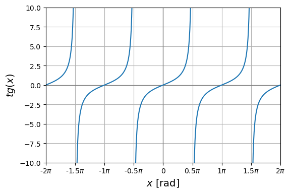

```python
import numpy as np
import math

x_min = -2 * math.pi
x_max = 2 * math.pi
x_step = (x_max - x_min) / 1000
x_values = np.arange(x_min, x_max + x_step, x_step)
y_values = np.tan(x_values)
y_values[:-1][np.diff(y_values) < 0] = np.nan

plt.grid()
plt.axhline(y=0.0, color='grey', linestyle='-', linewidth=1)
plt.axvline(x=0.0, color='grey', linestyle='-', linewidth=1)
plt.xlim(x_min, x_max)
plt.xlabel("$x$ [rad]", fontsize=14)
plt.ylabel("$tg(x)$", fontsize=14)
plt.ylim(-10, 10)
radian_multiples = np.arange(x_min / math.pi, x_max / math.pi + 0.5, 0.5) # [-2, -3/2, -1, -1/2, 0, 1/2, 1, 3/2]
radians = [n * math.pi for n in radian_multiples]
radian_labels = []
for n in radian_multiples:
    label = '0' if n == 0 else rf'{int(n)}$\pi$' if n == int(n) else rf'{n}$\pi$'
    radian_labels.append(label)

plt.xticks(radians, radian_labels)
plt.plot(x_values, y_values)
plt.show()
```